# Ulva and Hypnea GROWTH Rate Percentage

Angela Richards Donà

10/11/2022

## GROWTH RATE Analysis, Script Chunks, and Plots

This is the analysis of the numerous runs of the Ulva and Hypnea salinity and nutrient experiments conducted on the lanai in St. John 616. These experiments incorporated three temperature levels. Data gaps for both species filled in April 2022 and subsequently in October 2022. This output reflects all data totaling six treatments for Hypnea and five for Ulva. Treatment 2.5 for Ulva was removed due to excessive tissue sloughing.

Packages loaded:

```r
library(lme4)
library(lmerTest)
library(effects)
library(car)
library(MuMIn)
library (dplyr)
library(emmeans)
library(DHARMa)
library(performance)
library(patchwork)
library(rstatix)
#for plots and tables
library(ggplot2)
library(ggpubr)
library(forcats)
library(RColorBrewer)
library(tidyverse)
library(sjPlot)
library(sjmisc)
#library(mmtable2)
library(gt)
library(purrr)
library(stringr)
library(tidyr)
library(piecewiseSEM)
```

Open weight dataset and make columns for growth rate from initial and final weights

```r
all_growth <- read.csv("/Users/Angela/src/work/limu/algal_growth_photosynthesis/data_input/all_runs_growth_011723.csv")
```

Make a new column for weight change (difference final from initial)

```r
all_growth$growth_rate_percent <- (all_growth$final.weight - all_growth$Initial.weight) / all_growth$Initial.weight * 100
```

Make a new column for daily growth rate from 8 day study (steady growth rate assumed rather than exponential)

```r
all_growth$steady_growth_daily <- all_growth$growth_rate_percent / 8
```

Make a new column that keeps only the numerical values (effectively removes the C in temperatures for consistency)

```r
all_growth$temp_clean <- as.factor(substr(all_growth$temperature, 1, 2))
```

Assign several variables as factors

```r
all_growth$temperature <- as.factor(all_growth$temp_clean)
all_growth$treatment <- as.factor(as.character(all_growth$treatment))
all_growth$run <- as.factor(all_growth$run)
all_growth$plant.ID <- as.factor(all_growth$plant.ID)
all_growth$RLC.order <- as.factor(all_growth$RLC.order)
all_growth$lunar.phase <- as.factor(all_growth$lunar.phase)
```

ULVA__________________________________________________________________________________________ Subset data by species

```r
ulva <- subset(all_growth, Species == "Ul" & treatment != 2.5)
```

Create new column with treatment specifications

```r
ulva$treatment_graph[ulva$treatment == 0] <- "1) 35ppt/0.5umol"
ulva$treatment_graph[ulva$treatment == 1] <- "2) 35ppt/14umol"
ulva$treatment_graph[ulva$treatment == 2] <- "3) 28ppt/27umol"
ulva$treatment_graph[ulva$treatment == 3] <- "5) 18ppt/53umol"
ulva$treatment_graph[ulva$treatment == 4] <- "6) 11ppt/80umol"
#ulva$treatment_graph[ulva$treatment == 2.5] <- "4) 28ppt/53umol"
```

Make a histogram of the data for ulva

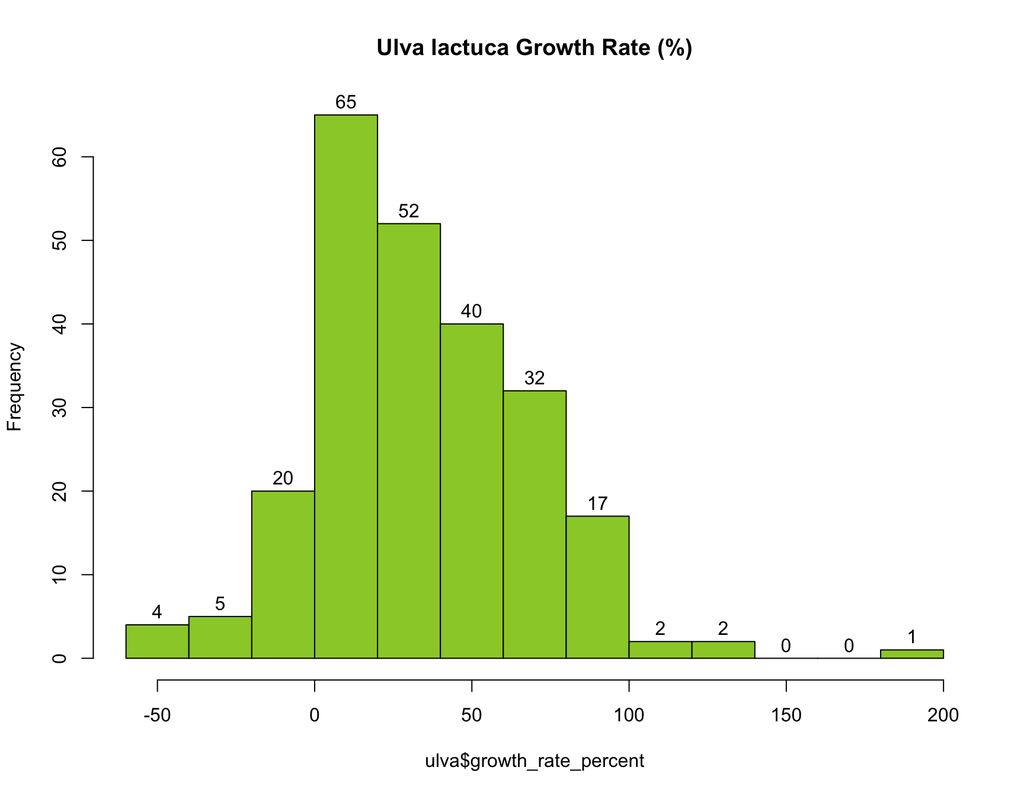

```r
hist(ulva$growth_rate_percent, main = paste("Ulva lactuca Growth Rate (%)"), col = "olivedrab3", labels = TRUE)
```

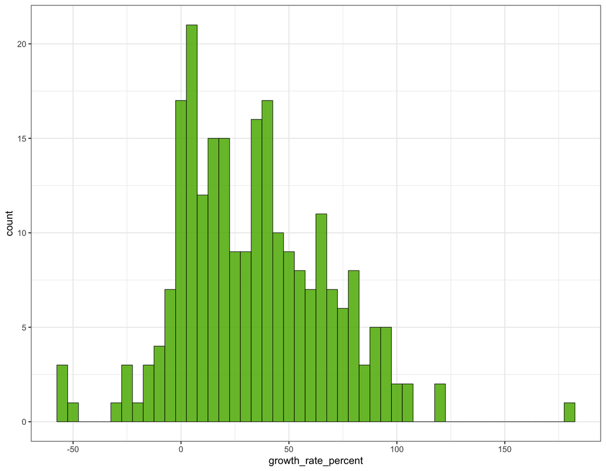

```r
#or
ulva %>% ggplot(aes(growth_rate_percent)) +
  geom_histogram(binwidth=5, fill = "#5BB300", color = "black", size = 0.25, alpha = 0.85) +
  theme_bw()
```

Run model without interaction

```r
growth_model_ulva <- lmer(formula = growth_rate_percent ~ treatment + temperature +
                                 (1 | plant.ID) + (1 | lunar.phase), data = ulva, REML = TRUE)
```

Plot residuals

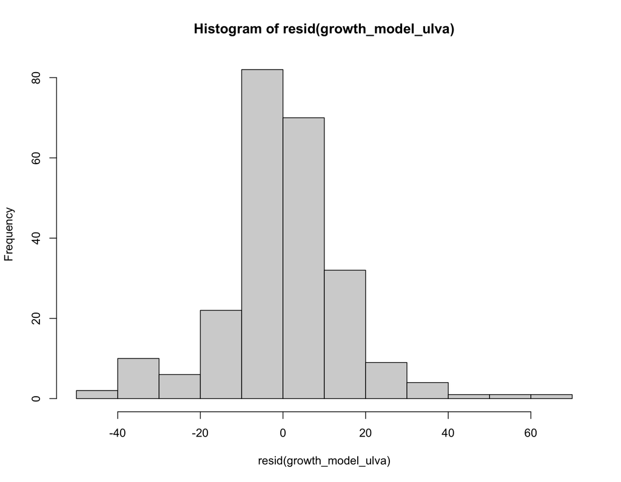

```r
hist(resid(growth_model_ulva))
```

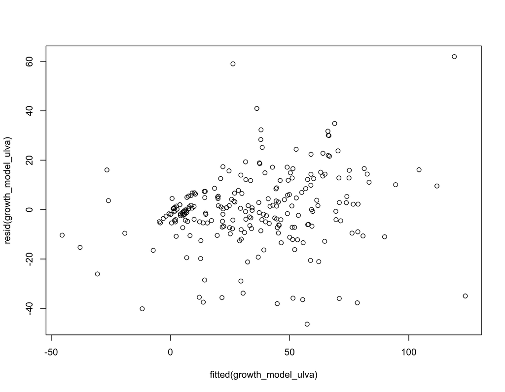

```r
plot(resid(growth_model_ulva) ~ fitted(growth_model_ulva))
```

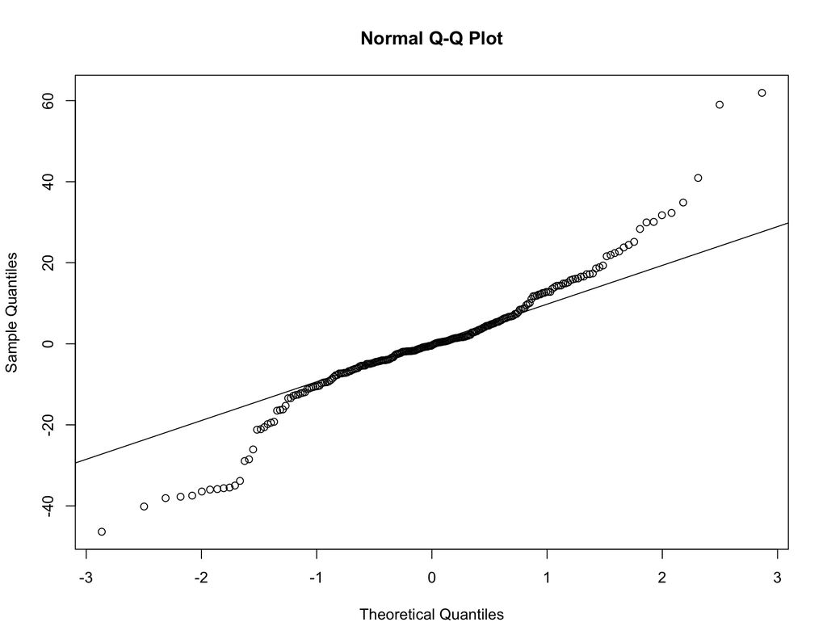

```r
qqnorm(resid(growth_model_ulva))
qqline(resid(growth_model_ulva))
```

Check the performance of the model for dataset: ulva, make table, plot effects, get r2

```r
performance::check_model(growth_model_ulva)
```

```
## Variable `Component` is not in your data frame :/
```

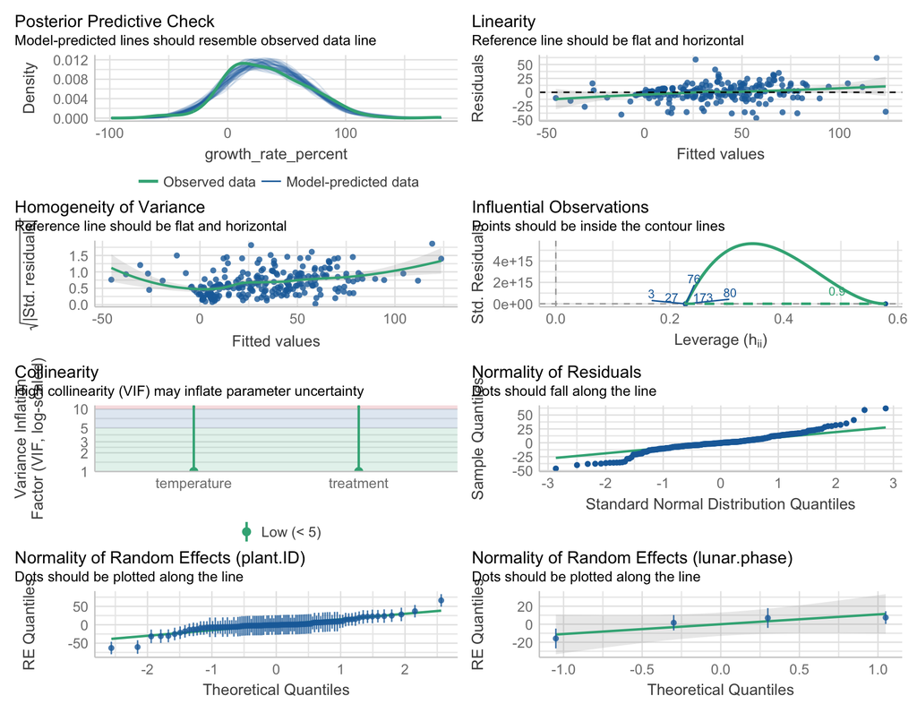

```r
rsquared(growth_model_ulva)
```

```
##              Response   family     link method Marginal Conditional
## 1 growth_rate_percent gaussian identity   none  0.26076    0.727439
```

```r
summary(growth_model_ulva)
```

```
## Linear mixed model fit by REML. t-tests use Satterthwaite's method [
## lmerModLmerTest]
## Formula: growth_rate_percent ~ treatment + temperature + (1 | plant.ID) +
##     (1 | lunar.phase)
##    Data: ulva
##
## REML criterion at convergence: 2156.6
##
## Scaled residuals:
##     Min      1Q  Median      3Q     Max
## -2.5952 -0.3489 -0.0222  0.3738  3.4647
##
## Random effects:
##  Groups      Name        Variance Std.Dev.
##  plant.ID    (Intercept) 401.2    20.03
##  lunar.phase (Intercept) 145.6    12.07
##  Residual                319.3    17.87
## Number of obs: 240, groups:  plant.ID, 96; lunar.phase, 4
##
## Fixed effects:
##               Estimate Std. Error       df t value Pr(>|t|)
## (Intercept)     0.9359     8.4622   6.5462   0.111    0.915
## treatment1     29.8879     6.2888 129.1863   4.753 5.27e-06 ***
## treatment2     37.4082     6.2888 129.1863   5.948 2.38e-08 ***
## treatment3     44.6986     6.2888 129.1863   7.108 7.14e-11 ***
## treatment4     49.3123     6.2888 129.1863   7.841 1.46e-12 ***
## temperature27  -1.0465     6.0046 105.7447  -0.174    0.862
## temperature30  -1.8413     6.0046 105.7447  -0.307    0.760
## ---
## Signif. codes:  0 '***' 0.001 '**' 0.01 '*' 0.05 '.' 0.1 ' ' 1
##
## Correlation of Fixed Effects:
##             (Intr) trtmn1 trtmn2 trtmn3 trtmn4 tmpr27
## treatment1  -0.444
## treatment2  -0.444  0.832
## treatment3  -0.444  0.832  0.832
## treatment4  -0.444  0.832  0.832  0.832
## temperatr27 -0.355  0.000  0.000  0.000  0.000
## temperatr30 -0.355  0.000  0.000  0.000  0.000  0.500
```

```r
tab_model(growth_model_ulva, show.intercept = TRUE, show.se = TRUE, show.stat = TRUE, show.df = TRUE, show.zeroinf = TRUE)
```

|  | growth_rate_percent |  |  |  |  |  |
| --- | --- | --- | --- | --- | --- | --- |
| Predictors | Estimates | std. Error | CI | Statistic | p | df |
| (Intercept) | 0.94 | 8.46 | -15.74 – 17.61 | 0.11 | 0.912 | 230.00 |
| treatment [1] | 29.89 | 6.29 | 17.50 – 42.28 | 4.75 | **<0.001** | 230.00 |
| treatment [2] | 37.41 | 6.29 | 25.02 – 49.80 | 5.95 | **<0.001** | 230.00 |
| treatment [3] | 44.70 | 6.29 | 32.31 – 57.09 | 7.11 | **<0.001** | 230.00 |
| treatment [4] | 49.31 | 6.29 | 36.92 – 61.70 | 7.84 | **<0.001** | 230.00 |
| temperature [27] | -1.05 | 6.00 | -12.88 – 10.78 | -0.17 | 0.862 | 230.00 |
| temperature [30] | -1.84 | 6.00 | -13.67 – 9.99 | -0.31 | 0.759 | 230.00 |
| Random Effects |  |  |  |  |  |  |
| σ<sup>2</sup> | 319.34 |  |  |  |  |  |
| τ<sub>00</sub> <sub>plant.ID</sub> | 401.17 |  |  |  |  |  |
| τ<sub>00</sub> <sub>lunar.phase</sub> | 145.60 |  |  |  |  |  |
| ICC | 0.63 |  |  |  |  |  |
| N <sub>plant.ID</sub> | 96 |  |  |  |  |  |
| N <sub>lunar.phase</sub> | 4 |  |  |  |  |  |
| Observations | 240 |  |  |  |  |  |
| Marginal R<sup>2</sup> / Conditional R<sup>2</sup> | 0.261 / 0.727 |  |  |  |  |  |

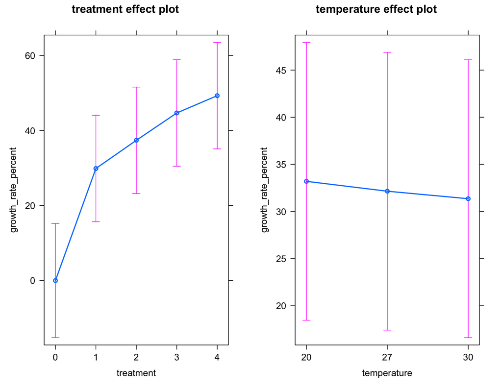

```r
plot(allEffects(growth_model_ulva))
```

Construct null model to perform likelihood ratio test REML must be FALSE

```r
ulva_growth_treatment_null <- lmer(formula = growth_rate_percent ~ temperature + (1 | lunar.phase) + (1 | plant.ID), data = ulva, REML = FALSE)
ulva_growth_model2 <- lmer(formula = growth_rate_percent ~ treatment + temperature + (1 |lunar.phase) + (1 | plant.ID), data = ulva, REML = FALSE)
anova(ulva_growth_treatment_null, ulva_growth_model2)
```

```
## Data: ulva
## Models:
## ulva_growth_treatment_null: growth_rate_percent ~ temperature + (1 | lunar.phase) + (1 | plant.ID)
## ulva_growth_model2: growth_rate_percent ~ treatment + temperature + (1 | lunar.phase) + (1 | plant.ID)
##                            npar    AIC    BIC  logLik deviance  Chisq Df
## ulva_growth_treatment_null    6 2272.3 2293.2 -1130.2   2260.3
## ulva_growth_model2           10 2210.5 2245.3 -1095.2   2190.5 69.852  4
##                            Pr(>Chisq)
## ulva_growth_treatment_null
## ulva_growth_model2           2.44e-14 ***
## ---
## Signif. codes:  0 '***' 0.001 '**' 0.01 '*' 0.05 '.' 0.1 ' ' 1
```

```r
ulva_growth_temperature_null <- lmer(formula = growth_rate_percent ~ treatment + (1 | lunar.phase) + (1 | plant.ID), data = ulva, REML = FALSE)
ulva_growth_model3 <- lmer(formula = growth_rate_percent ~ treatment + temperature + (1 | lunar.phase) + (1 | plant.ID), data = ulva, REML = FALSE)
anova(ulva_growth_temperature_null, ulva_growth_model3)
```

```
## Data: ulva
## Models:
## ulva_growth_temperature_null: growth_rate_percent ~ treatment + (1 | lunar.phase) + (1 | plant.ID)
## ulva_growth_model3: growth_rate_percent ~ treatment + temperature + (1 | lunar.phase) + (1 | plant.ID)
##                              npar    AIC    BIC  logLik deviance  Chisq Df
## ulva_growth_temperature_null    8 2206.6 2234.4 -1095.3   2190.6
## ulva_growth_model3             10 2210.5 2245.3 -1095.2   2190.5 0.0976  2
##                              Pr(>Chisq)
## ulva_growth_temperature_null
## ulva_growth_model3               0.9524
```

Plots

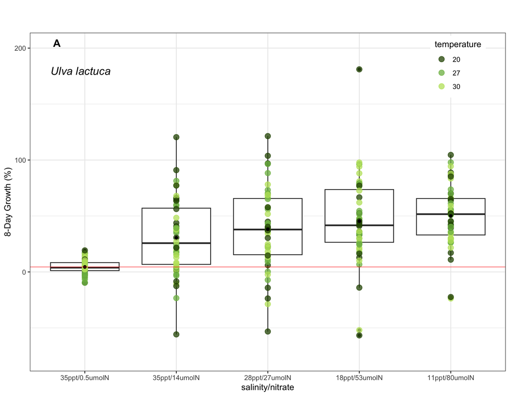

```r
ulva %>% ggplot(aes(treatment_graph, growth_rate_percent)) +
  geom_boxplot(size=0.5) +
  geom_point(alpha = 0.75, size = 3, aes(color = temperature), show.legend = TRUE) +
  labs(x="salinity/nitrate", y= "8-Day Growth (%)", title= "A", subtitle = "Ulva lactuca") +
  scale_x_discrete(labels = c("35ppt/0.5umolN", "35ppt/14umolN", "28ppt/27umolN", "18ppt/53umolN", "11ppt/80umolN")) +
  ylim(-75, 200) + stat_mean() +
  scale_color_manual(values = c("#295102", "#7CB950", "#BDE269")) +
  geom_hline(yintercept=4.46, color = "red", size = 0.5, alpha = 0.5) +
  theme_bw() +
  theme(legend.position = c(0.90,0.90), plot.title = element_text(face = "bold", vjust = -15, hjust = 0.05),
        plot.subtitle = element_text(face = "italic", size = 14, vjust = -20, hjust = 0.05))
```

Summarize the means

```r
ulva %>% group_by(treatment) %>% summarise_at(vars(growth_rate_percent), list(mean = mean))
```

```
## # A tibble: 5 × 2
##   treatment  mean
##   <fct>     <dbl>
## 1 0          4.46
## 2 1         30.6
## 3 2         38.1
## 4 3         45.4
## 5 4         50.0
```

HYPNEA______________________________________________________________________

Removing hm6-4 on 11/12/21 because it was dead and had no D9 RLC (final weight 0.1017) and hm6-4 on 10/29/21 because it was white and also looked dead

```r
hypnea <- subset(all_growth, Species == "Hm" & growth_rate_percent > -87.96837 & final.weight != 0.1017)
```

For plots, add column with treatment specifications

```r
hypnea$treatment_graph[hypnea$treatment == 0] <- "1) 35ppt/0.5umol"
hypnea$treatment_graph[hypnea$treatment == 1] <- "2) 35ppt/14umol"
hypnea$treatment_graph[hypnea$treatment == 2] <- "3) 28ppt/27umol"
hypnea$treatment_graph[hypnea$treatment == 3] <- "5) 18ppt/53umol"
hypnea$treatment_graph[hypnea$treatment == 4] <- "6) 11ppt/80umol"
hypnea$treatment_graph[hypnea$treatment == 2.5] <- "4) 28ppt/53umol"
```

Make a histogram of the data for hypnea

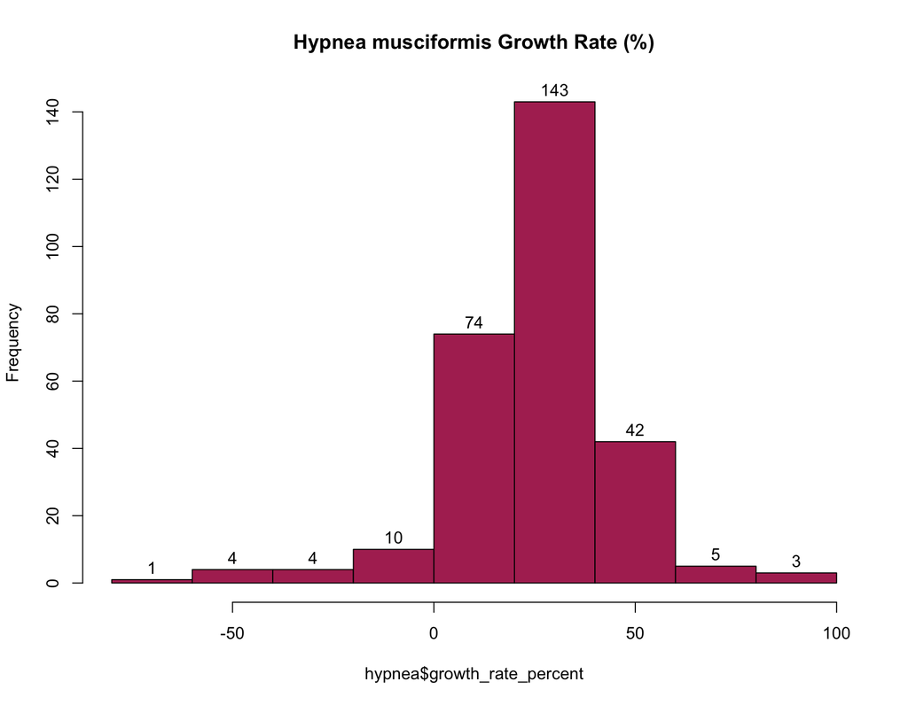

```r
hist(hypnea$growth_rate_percent, main = paste("Hypnea musciformis Growth Rate (%)"), col = "maroon", labels = TRUE)
```

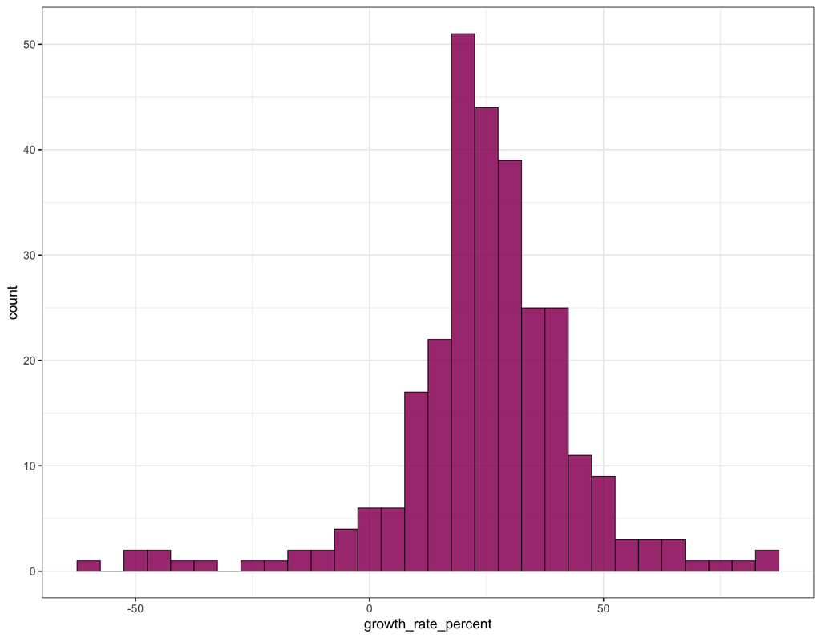

```r
hypnea %>% ggplot(aes(growth_rate_percent)) +
  geom_histogram(binwidth=5, fill = "#990066", color = "black", size = 0.25, alpha = 0.85) +
  theme_bw()
```

Run model without interaction

```r
growth_model_hypnea <- lmer(formula = growth_rate_percent ~ treatment + temperature + (1 | plant.ID) +
                                 (1 | run) + (1 | RLC.order), data = hypnea, REML = TRUE)
```

Plot residuals for hypnea growth model

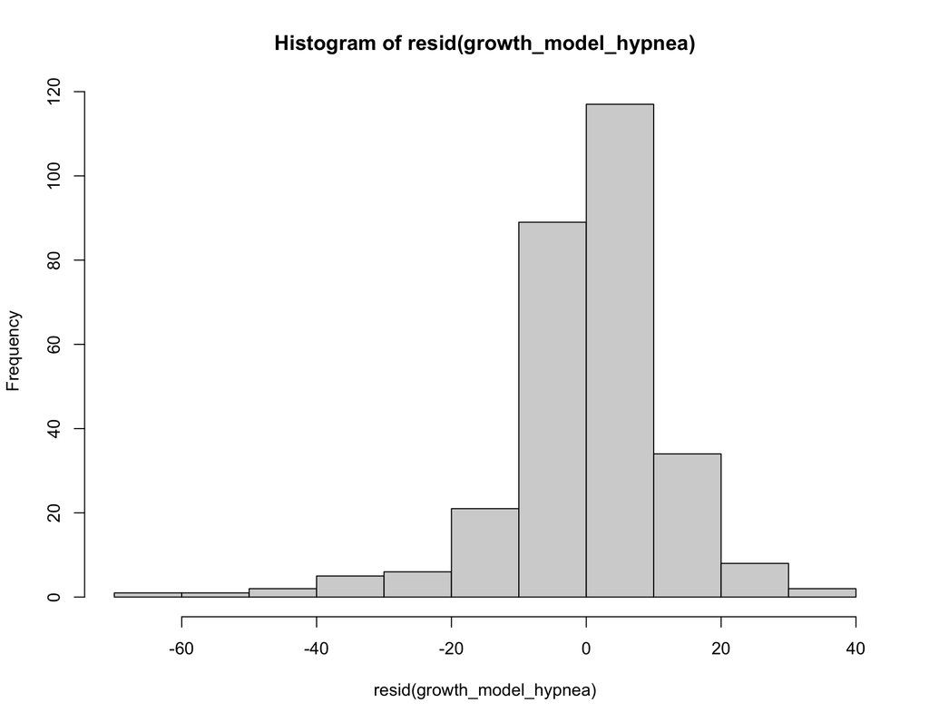

```r
hist(resid(growth_model_hypnea))
```

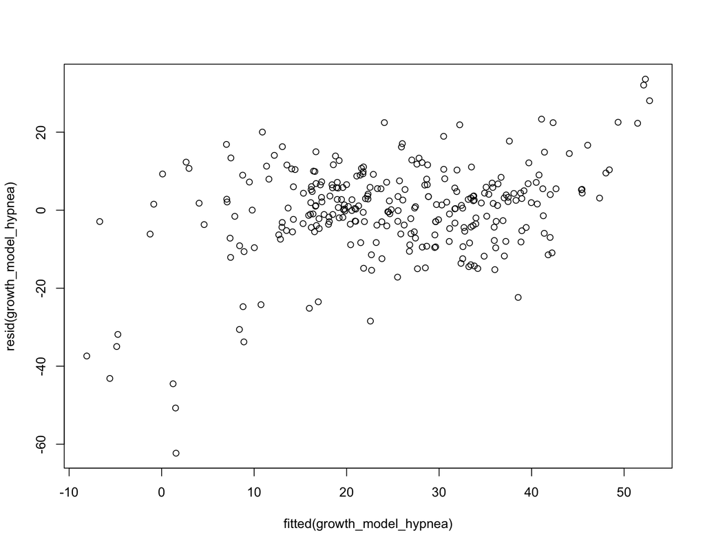

```r
plot(resid(growth_model_hypnea) ~ fitted(growth_model_hypnea))
```

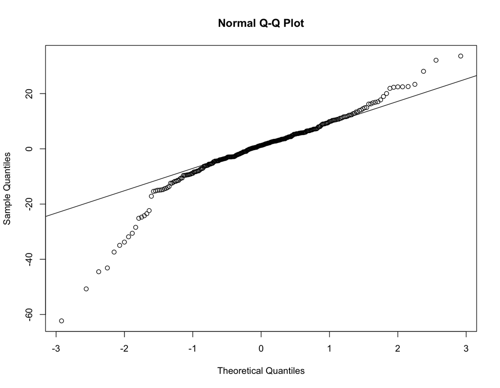

```r
qqnorm(resid(growth_model_hypnea))
qqline(resid(growth_model_hypnea))
```

Check the performance of the model, make table, plot effects, get r2

```r
performance::check_model(growth_model_hypnea)
```

```
## Variable `Component` is not in your data frame :/
```

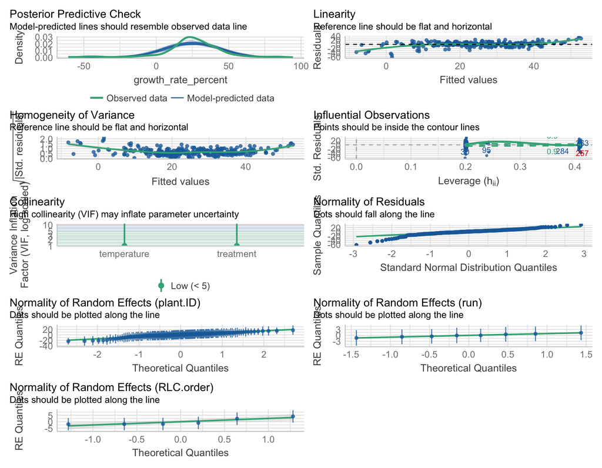

```r
r.squaredGLMM(growth_model_hypnea)
```

```
##           R2m      R2c
## [1,] 0.152829 0.504778
```

```r
summary(growth_model_hypnea)
```

```
## Linear mixed model fit by REML. t-tests use Satterthwaite's method [
## lmerModLmerTest]
## Formula: growth_rate_percent ~ treatment + temperature + (1 | plant.ID) +
##     (1 | run) + (1 | RLC.order)
##    Data: hypnea
##
## REML criterion at convergence: 2396.1
##
## Scaled residuals:
##     Min      1Q  Median      3Q     Max
## -4.4292 -0.3155  0.0868  0.4608  2.3888
##
## Random effects:
##  Groups    Name        Variance Std.Dev.
##  plant.ID  (Intercept) 122.13   11.051
##  run       (Intercept)   4.69    2.166
##  RLC.order (Intercept)  13.79    3.713
##  Residual              197.84   14.066
## Number of obs: 286, groups:  plant.ID, 144; run, 8; RLC.order, 6
##
## Fixed effects:
##               Estimate Std. Error     df t value Pr(>|t|)
## (Intercept)     22.031      4.040  7.248   5.453 0.000847 ***
## treatment1      15.264      4.085  4.981   3.736 0.013573 *
## treatment2       3.765      4.085  4.981   0.922 0.399203
## treatment2.5    15.999      4.513  1.650   3.545 0.093455 .
## treatment3       5.168      4.085  4.981   1.265 0.261765
## treatment4      -4.486      4.111  5.119  -1.091 0.323954
## temperature27   -4.748      4.069 16.891  -1.167 0.259395
## temperature30   -4.933      3.737 41.434  -1.320 0.194064
## ---
## Signif. codes:  0 '***' 0.001 '**' 0.01 '*' 0.05 '.' 0.1 ' ' 1
##
## Correlation of Fixed Effects:
##             (Intr) trtmn1 trtmn2 trt2.5 trtmn3 trtmn4 tmpr27
## treatment1  -0.546
## treatment2  -0.546  0.753
## treatmnt2.5 -0.494  0.489  0.489
## treatment3  -0.546  0.753  0.753  0.489
## treatment4  -0.543  0.748  0.748  0.486  0.748
## temperatr27 -0.484  0.000  0.000  0.000  0.000 -0.002
## temperatr30 -0.469  0.000  0.000  0.000  0.000  0.005  0.480
```

```r
tab_model(growth_model_hypnea, show.intercept = TRUE, show.se = TRUE, show.stat = TRUE, show.df = TRUE, show.zeroinf = TRUE)
```

|  | growth_rate_percent |  |  |  |  |  |
| --- | --- | --- | --- | --- | --- | --- |
| Predictors | Estimates | std. Error | CI | Statistic | p | df |
| (Intercept) | 22.03 | 4.04 | 14.08 – 29.98 | 5.45 | **<0.001** | 274.00 |
| treatment [1] | 15.26 | 4.09 | 7.22 – 23.31 | 3.74 | **<0.001** | 274.00 |
| treatment [2] | 3.76 | 4.09 | -4.28 – 11.81 | 0.92 | 0.358 | 274.00 |
| treatment [2.5] | 16.00 | 4.51 | 7.11 – 24.88 | 3.55 | **<0.001** | 274.00 |
| treatment [3] | 5.17 | 4.09 | -2.87 – 13.21 | 1.27 | 0.207 | 274.00 |
| treatment [4] | -4.49 | 4.11 | -12.58 – 3.61 | -1.09 | 0.276 | 274.00 |
| temperature [27] | -4.75 | 4.07 | -12.76 – 3.26 | -1.17 | 0.244 | 274.00 |
| temperature [30] | -4.93 | 3.74 | -12.29 – 2.42 | -1.32 | 0.188 | 274.00 |
| Random Effects |  |  |  |  |  |  |
| σ<sup>2</sup> | 197.84 |  |  |  |  |  |
| τ<sub>00</sub> <sub>plant.ID</sub> | 122.13 |  |  |  |  |  |
| τ<sub>00</sub> <sub>run</sub> | 4.69 |  |  |  |  |  |
| τ<sub>00</sub> <sub>RLC.order</sub> | 13.79 |  |  |  |  |  |
| ICC | 0.42 |  |  |  |  |  |
| N <sub>plant.ID</sub> | 144 |  |  |  |  |  |
| N <sub>run</sub> | 8 |  |  |  |  |  |
| N <sub>RLC.order</sub> | 6 |  |  |  |  |  |
| Observations | 286 |  |  |  |  |  |
| Marginal R<sup>2</sup> / Conditional R<sup>2</sup> | 0.153 / 0.505 |  |  |  |  |  |

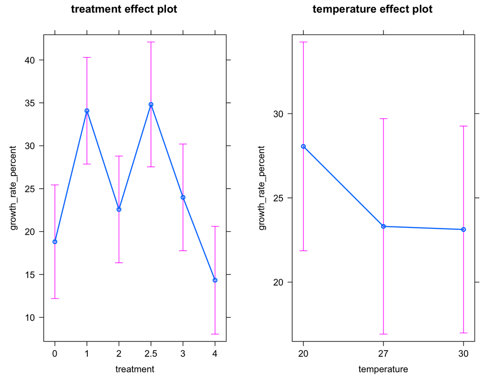

```r
plot(allEffects(growth_model_hypnea))
```

Construct null model to perform likelihood ratio test REML must be FALSE

```r
hypnea_growth_treatment_null <- lmer(formula = growth_rate_percent ~ temperature + (1 | plant.ID) + (1 | run) + (1 | RLC.order), data = hypnea, REML = FALSE)
hypnea_growth_model2 <- lmer(formula = growth_rate_percent ~ treatment + temperature + (1 | plant.ID) + (1 | run) + (1 | RLC.order), data = hypnea, REML = FALSE)
```

```
## boundary (singular) fit: see help('isSingular')
```

```r
anova(hypnea_growth_treatment_null, hypnea_growth_model2)
```

```
## Data: hypnea
## Models:
## hypnea_growth_treatment_null: growth_rate_percent ~ temperature + (1 | plant.ID) + (1 | run) + (1 | RLC.order)
## hypnea_growth_model2: growth_rate_percent ~ treatment + temperature + (1 | plant.ID) + (1 | run) + (1 | RLC.order)
##                              npar    AIC    BIC  logLik deviance  Chisq Df
## hypnea_growth_treatment_null    7 2491.0 2516.6 -1238.5   2477.0
## hypnea_growth_model2           12 2451.3 2495.2 -1213.6   2427.3 49.765  5
##                              Pr(>Chisq)
## hypnea_growth_treatment_null
## hypnea_growth_model2          1.548e-09 ***
## ---
## Signif. codes:  0 '***' 0.001 '**' 0.01 '*' 0.05 '.' 0.1 ' ' 1
```

```r
hypnea_growth_temperature_null <- lmer(formula = growth_rate_percent ~ treatment + (1 | plant.ID) + (1 | run) + (1 | RLC.order), data = hypnea, REML = FALSE)
```

```
## boundary (singular) fit: see help('isSingular')
```

```r
hypnea_growth_model3 <- lmer(formula = growth_rate_percent ~ treatment + temperature + (1 | plant.ID) + (1 | run) + (1 | RLC.order), data = hypnea, REML = FALSE)
```

```
## boundary (singular) fit: see help('isSingular')
```

```r
anova(hypnea_growth_temperature_null, hypnea_growth_model3)
```

```
## Data: hypnea
## Models:
## hypnea_growth_temperature_null: growth_rate_percent ~ treatment + (1 | plant.ID) + (1 | run) + (1 | RLC.order)
## hypnea_growth_model3: growth_rate_percent ~ treatment + temperature + (1 | plant.ID) + (1 | run) + (1 | RLC.order)
##                                npar    AIC    BIC  logLik deviance  Chisq Df
## hypnea_growth_temperature_null   10 2449.8 2486.4 -1214.9   2429.8
## hypnea_growth_model3             12 2451.3 2495.2 -1213.6   2427.3 2.5309  2
##                                Pr(>Chisq)
## hypnea_growth_temperature_null
## hypnea_growth_model3               0.2821
```

Plots

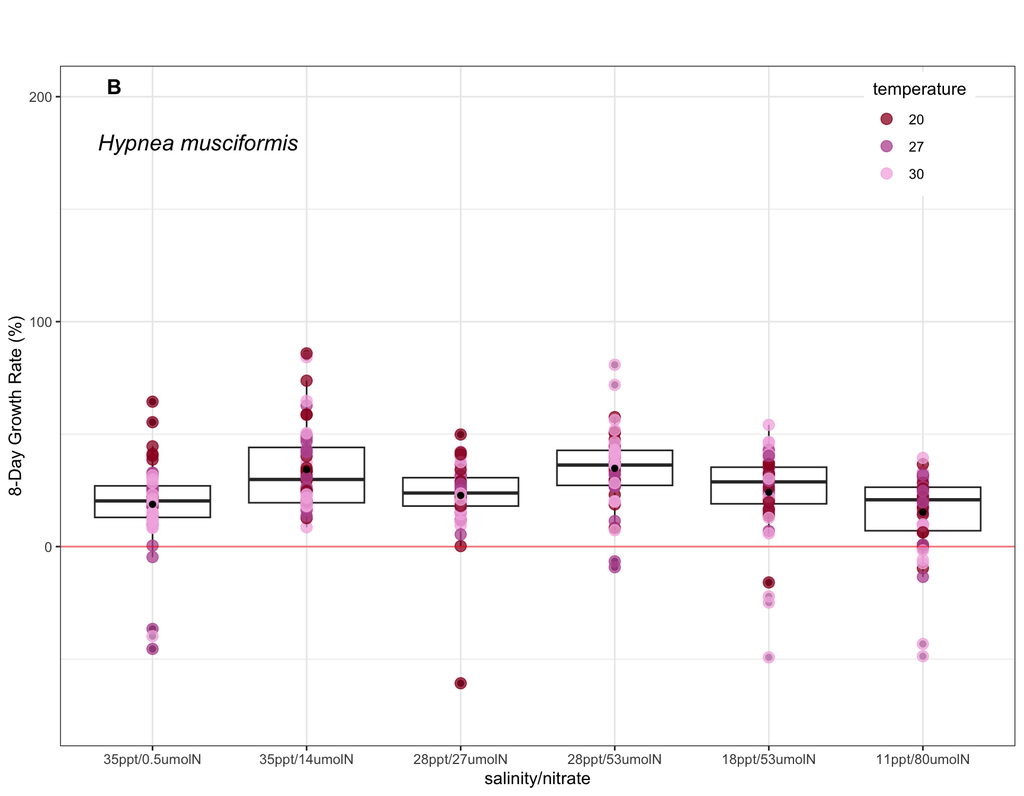

```r
hypnea %>% ggplot(aes(treatment_graph, growth_rate_percent)) +
  geom_boxplot(size=0.5) +
  geom_point(alpha = 0.75, size = 3, aes(color = temperature), show.legend = TRUE) +
  labs(x="salinity/nitrate", y= "8-Day Growth Rate (%)", title= "B", subtitle = "Hypnea musciformis") +
  scale_x_discrete(labels = c("35ppt/0.5umolN", "35ppt/14umolN", "28ppt/27umolN", "28ppt/53umolN", "18ppt/53umolN", "11ppt/80umolN")) +
  ylim(-75, 200) + stat_mean() +
  scale_color_manual(values = c("#9C0627", "#BB589F", "#F4B4E2")) +
  geom_hline(yintercept=0, color = "red", size = 0.5, alpha = 0.5) +
  theme_bw() +
  theme(legend.position = c(0.90,0.90), plot.title = element_text(face = "bold", vjust = -15, hjust = 0.05),
        plot.subtitle = element_text(face = "italic", size = 14, vjust = -20, hjust = 0.05))
```

Summarize the means

```r
hypnea %>% group_by(treatment) %>% summarise_at(vars(growth_rate_percent), list(mean = mean))
```

```
## # A tibble: 6 × 2
##   treatment  mean
##   <fct>     <dbl>
## 1 0          18.8
## 2 1          34.2
## 3 2          22.7
## 4 2.5        34.8
## 5 3          24.1
## 6 4          15.3
```